# Pneumonia Prediction Using Vision Transformer (ViT)

Dataset: [Kaggle Chest X-ray Pneumonia](https://www.kaggle.com/datasets/paultimothymooney/chest-xray-pneumonia)

##### Pneumonia is an inflammatory condition primarily affecting the alveoli, the microscopic air sacs within the lungs.It usually manifests as fever dyspnea chest pain and a cough that can be dry or productive to start. People can differ greatly in how severe their pneumonia is. The condition can also be caused by fungal organisms certain medications or underlying medical conditions such as autoimmune diseases although bacterial and viral pathogens are the most common causes. A number of conditions such as asthma diabetes mellitus congestive heart failure chronic obstructive pulmonary disease (COPD) immunosuppression a history of smoking and an impaired cough reflex (e. g. G. following a stroke) as well as hereditary conditions like cystic fibrosis. Diagnostic instruments like sputum cultures blood tests and chest radiography may be used to support the diagnosis which is frequently based on clinical evaluation and physical examination. Clinically pneumonia is divided into three categories: community-acquired hospital-acquired and healthcare-associated.

```python
# IMPORTS
import os
import cv2
import numpy as np
import pandas as pd
import matplotlib.pyplot as plt
import seaborn as sns
import tensorflow as tf
from tensorflow import keras
from tensorflow.keras.preprocessing import image_dataset_from_directory
from tensorflow.keras import layers
from tensorflow.keras.models import Model
from tensorflow.keras.callbacks import EarlyStopping
from tensorflow.keras.losses import BinaryCrossentropy
from tensorflow.keras.optimizers import Adamax
from sklearn.preprocessing import LabelEncoder
from sklearn.metrics import classification_report, confusion_matrix, roc_auc_score, roc_curve, auc
from transformers import TFViTModel
import warnings
warnings.filterwarnings("ignore")
```

```python
# PATHS
def create_dataframe_from_directory(directory):
    filepaths, labels = [], []
    for label in os.listdir(directory):
        path = os.path.join(directory, label)
        for file in os.listdir(path):
            filepaths.append(os.path.join(path, file))
            labels.append(label)
    return pd.DataFrame({'filepath': filepaths, 'label': labels})

test_dataset = image_dataset_from_directory(
    "C:/Users/jiver/Downloads/CHEST/chest_xray/test",  # adjust path if needed
    image_size=(224, 224),
    batch_size=32,
    shuffle=False
)

base_path = 'C:/Users/jiver/Downloads/CHEST/chest_xray'  # Windows-friendly path
df_train = create_dataframe_from_directory(os.path.join(base_path, 'train'))
df_val = create_dataframe_from_directory(os.path.join(base_path, 'val'))
df_test = create_dataframe_from_directory(os.path.join(base_path, 'test'))

print(f"Train: {df_train.shape}, Val: {df_val.shape}, Test: {df_test.shape}")
```

```
Found 624 files belonging to 2 classes.
Train: (5216, 2), Val: (16, 2), Test: (624, 2)
```

```python
# IMAGE DATA

IMAGE_SIZE = (224, 224)
BATCH_SIZE = 32
SEED = 123

# Data Augmentation Block (Keras Sequential API)
data_augmentation = tf.keras.Sequential([
    layers.RandomFlip("horizontal"),
    layers.RandomRotation(0.1),
    layers.RandomZoom(0.2),
    layers.RandomTranslation(0.1, 0.1)
], name="data_augmentation")

train_ds = tf.keras.utils.image_dataset_from_directory(
    os.path.join(base_path, "train"),
    seed=SEED,
    validation_split=0.1,
    subset="training",
    image_size=IMAGE_SIZE,
    batch_size=BATCH_SIZE
)

val_ds = tf.keras.utils.image_dataset_from_directory(
    os.path.join(base_path, "train"),
    seed=SEED,
    validation_split=0.1,
    subset="validation",
    image_size=IMAGE_SIZE,
    batch_size=BATCH_SIZE
)

test_ds = tf.keras.utils.image_dataset_from_directory(
    os.path.join(base_path, "test"),
    seed=SEED,
    image_size=IMAGE_SIZE,
    batch_size=BATCH_SIZE
)

# Save the class names BEFORE applying .map()
class_names = train_ds.class_names

AUTOTUNE = tf.data.AUTOTUNE

# Normalize pixel values
train_ds = train_ds.map(lambda x, y: (data_augmentation(x, training=True) / 255.0, y))
val_ds = val_ds.map(lambda x, y: (x / 255.0, y))
test_ds = test_ds.map(lambda x, y: (x / 255.0, y))

train_ds = train_ds.prefetch(buffer_size=AUTOTUNE)
val_ds = val_ds.prefetch(buffer_size=AUTOTUNE)
test_ds = test_ds.prefetch(buffer_size=AUTOTUNE)
```

[output not shown]

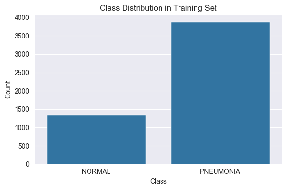

```python
# Prepare labels from the dataframe
label_names = ['PNEUMONIA' if label == 'PNEUMONIA' else 'NORMAL' for label in df_train['label']]
sns.set_style('darkgrid')
plt.figure(figsize=(6, 4))
sns.countplot(x=label_names)
plt.title("Class Distribution in Training Set")
plt.xlabel("Class")
plt.ylabel("Count")
plt.tight_layout()
plt.show()
```

There is a clear imbalance between the "PNEUMONIA" and "NORMAL" classes, with pneumonia cases significantly outnumbering normal cases.This class imbalance is important to address through data augmentation or weighted loss functions to prevent model bias during training.

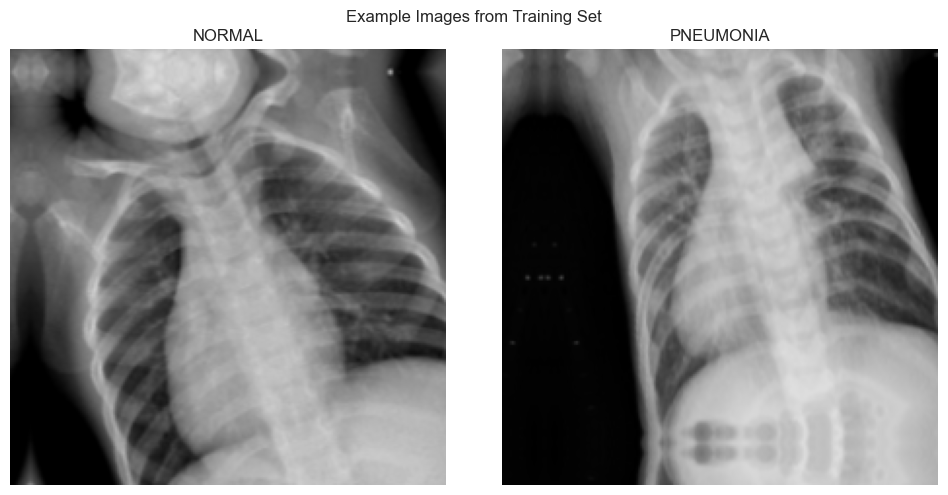

```python
# Preview one pneumonia and one normal image
def show_image_samples(dataset, class_names):
    for images, labels in dataset.take(1):
        plt.figure(figsize=(10, 5))

        ax1 = plt.subplot(1, 2, 1)
        plt.imshow(images[0].numpy().squeeze(), cmap='gray')
        plt.title(class_names[labels[0]])
        plt.axis("off")

        ax2 = plt.subplot(1, 2, 2)
        plt.imshow(images[-1].numpy().squeeze(), cmap='gray')
        plt.title(class_names[labels[-1]])
        plt.axis("off")

    plt.suptitle("Example Images from Training Set")
    plt.tight_layout()
    plt.show()


# Call the function
show_image_samples(train_ds, class_names)
```

The displays above are two representative chest X-ray images drawn from the training set. Each image is shown in grayscale and has been preprocessed and normalized to prepare for input into deep learning models.

- Left image: This X-ray corresponds to a patient labeled as NORMAL, showing clear lung fields with no signs of opacities or consolidation.
- Right image: This image belongs to the PNEUMONIA class and displays increased opacity in the lung regions, which is a typical radiographic feature of pneumonia.

  These samples help visually confirm that the dataset contains distinct diagnostic patterns between the NORMAL and PNEUMONIA classes. They also validate that the preprocessing pipeline (resizing, normalization, and grayscale preservation) maintains clinically relevant features critical for effective model learning.

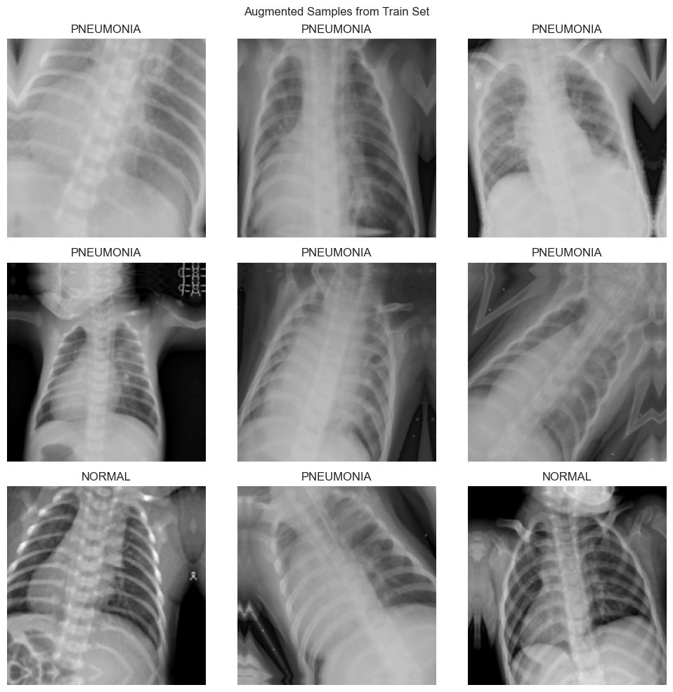

```python
for images, labels in train_ds.take(1):
    plt.figure(figsize=(10, 10))
    for i in range(9):
        ax = plt.subplot(3, 3, i + 1)
        plt.imshow(images[i].numpy(), cmap="gray")
        plt.title(class_names[labels[i]])
        plt.axis("off")
    plt.suptitle("Augmented Samples from Train Set")
    plt.tight_layout()
    plt.show()
```

The figure above presents a set of augmented chest X-ray images generated during training using the Vision Transformer (ViT) model pipeline. Data augmentation techniques such as random horizontal flipping, rotation, zooming, and translation have been applied to simulate the natural variability found in clinical imaging.

Despite these transformations, critical diagnostic features—such as lung opacities, rib and spine visibility, and chest contour integrity—remain preserved. This ensures that the model learns to identify pathology-relevant features even under image distortions.

In class-imbalanced datasets like this one, where PNEUMONIA cases significantly outnumber NORMAL samples, augmentation plays a vital role in improving model generalization and reducing overfitting. By artificially expanding the diversity of training examples, this strategy increases the model’s robustness and teaches it to focus on invariant clinical features that are essential for accurate pneumonia detection.

```python
# Load Vit
class ViTWrapper(layers.Layer):
    def __init__(self, vit_model, **kwargs):
        super().__init__(**kwargs)
        self.vit_model = vit_model

    def call(self, inputs):
        x = tf.transpose(inputs, perm=[0, 3, 1, 2])  # (B, 3, 224, 224)
        outputs = self.vit_model(pixel_values=x, output_attentions=True)
        self.attentions = outputs.attentions  # store attention maps
        return outputs.last_hidden_state

base_model = TFViTModel.from_pretrained('google/vit-base-patch16-224-in21k')
for layer in base_model.layers:
    layer.trainable = False

input_layer = keras.Input(shape=(224, 224, 3))
x = ViTWrapper(base_model)(input_layer)
x = layers.GlobalAveragePooling1D()(x)
x = layers.BatchNormalization()(x)
x = layers.Dropout(0.45)(x)
x = layers.Dense(220, activation='relu')(x)
x = layers.Dropout(0.25)(x)
x = layers.Dense(60, activation='relu')(x)
output_layer = layers.Dense(1, activation='sigmoid')(x)

model = keras.Model(inputs=input_layer, outputs=output_layer)
model.compile(optimizer=Adamax(learning_rate=0.001), loss='binary_crossentropy', metrics=['accuracy'])
model.summary()
```

```
All PyTorch model weights were used when initializing TFViTModel.

All the weights of TFViTModel were initialized from the PyTorch model.
If your task is similar to the task the model of the checkpoint was trained on, you can already use TFViTModel for predictions without further training.
```

```
Model: "model"
_________________________________________________________________
 Layer (type)                Output Shape              Param #
=================================================================
 input_1 (InputLayer)        [(None, 224, 224, 3)]     0

 vi_t_wrapper (ViTWrapper)   (None, 197, 768)          86389248

 global_average_pooling1d (G  (None, 768)              0
 lobalAveragePooling1D)

 batch_normalization (BatchN  (None, 768)              3072
 ormalization)

 dropout_148 (Dropout)       (None, 768)               0

 dense (Dense)               (None, 220)               169180

 dropout_149 (Dropout)       (None, 220)               0

 dense_1 (Dense)             (None, 60)                13260

 dense_2 (Dense)             (None, 1)                 61

=================================================================
Total params: 86,574,821
Trainable params: 184,037
Non-trainable params: 86,390,784
_________________________________________________________________
```

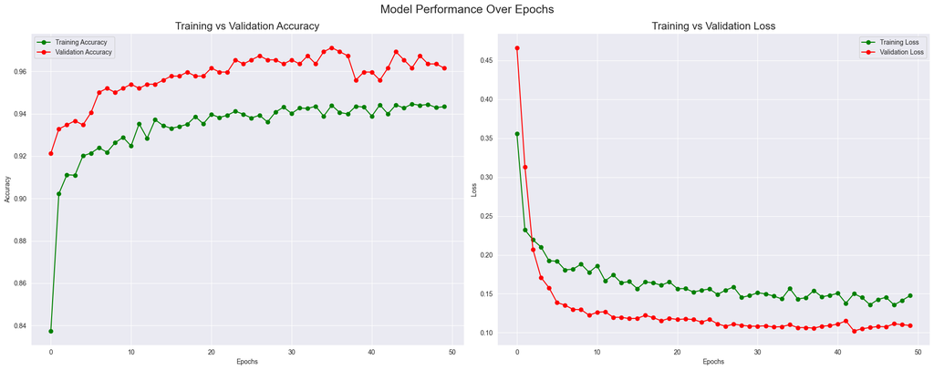

```python
# Early stopping
early_stopping = EarlyStopping(
    monitor='val_loss',
    patience=10,
    restore_best_weights=True
)

#  Model training with history
history = model.fit(
    train_ds,
    validation_data=val_ds,
    epochs=50,
    callbacks=[early_stopping]
)

#  Analysis after training (in same or next cell)
import matplotlib.pyplot as plt

# Get number of epochs dynamically
epochs = range(len(history.history['accuracy']))

# Set up plot
fig, ax = plt.subplots(1, 2, figsize=(20, 8))

# Accuracy plot
ax[0].plot(epochs, history.history['accuracy'], 'go-', label='Training Accuracy')
ax[0].plot(epochs, history.history['val_accuracy'], 'ro-', label='Validation Accuracy')
ax[0].set_title('Training vs Validation Accuracy', fontsize=16)
ax[0].set_xlabel('Epochs')
ax[0].set_ylabel('Accuracy')
ax[0].legend()
ax[0].grid(True)

# Loss plot
ax[1].plot(epochs, history.history['loss'], 'g-o', label='Training Loss')
ax[1].plot(epochs, history.history['val_loss'], 'r-o', label='Validation Loss')
ax[1].set_title('Training vs Validation Loss', fontsize=16)
ax[1].set_xlabel('Epochs')
ax[1].set_ylabel('Loss')
ax[1].legend()
ax[1].grid(True)

plt.suptitle("Model Performance Over Epochs", fontsize=18)
plt.tight_layout()
plt.show()
```